# Qualitative Activity Prediction of Weight Lifting Exercises

SiddharthIITG

20 October 2015

# Introduction

Using devices such as Jawbone Up, Nike FuelBand, and Fitbit it is now possible to collect a large amount of data about personal activity relatively inexpensively. These type of devices are part of the quantified self movement - a group of enthusiasts who take measurements about themselves regularly to improve their health, to find patterns in their behavior, or because they are tech geeks. One thing that people regularly do is quantify how much of a particular activity they do, but they rarely quantify how well they do it.

In this project, we will use data from accelerometers on the belt, forearm, arm, and dumbell of 6 participants to predict the manner in which they did the exercise.

# Executive Summary

- The estimated accuracy of the model used is 99.37%
- The out of sample error is 0.62%

# Loading Packages

```r
library("caTools")
library("randomForest")
library("rpart")
library("rpart.plot")
library("caret")
```

# Reading the data.

```r
train = read.csv("pml-training.csv")
test = read.csv("pml-testing.csv")
train = train[, colSums(is.na(train)) < 5] # NA columns
train = train[, colSums(train != "") > 1000] # empty columns
test = test[, colSums(is.na(test)) < 5] # NA columns
train = train[, 8:60] #removing time and name etc.
test = test[,8:60] #removing time and name etc
```

train and test both now contain 53 variables each.

## Creating a validation dataset by splitting the training set in 0.7 ratio.

```r
split = sample.split(train$classe, SplitRatio = 0.7)
trainData = subset(train, split==TRUE)
testData = subset(train, split==FALSE)
```

## Finding variables with near zero variance

```r
nzv <- nearZeroVar(trainData, saveMetrics=TRUE)
nzv
```

```
##                      freqRatio percentUnique zeroVar   nzv
## roll_belt             1.096463    8.05242082   FALSE FALSE
## pitch_belt            1.030534   12.23152530   FALSE FALSE
## yaw_belt              1.060345   12.98143429   FALSE FALSE
## total_accel_belt      1.078994    0.21113942   FALSE FALSE
## gyros_belt_x          1.074346    0.97560976   FALSE FALSE
## gyros_belt_y          1.156698    0.48780488   FALSE FALSE
## gyros_belt_z          1.076417    1.20131052   FALSE FALSE
## accel_belt_x          1.019892    1.16490717   FALSE FALSE
## accel_belt_y          1.121043    0.98289043   FALSE FALSE
## accel_belt_z          1.115894    2.09683291   FALSE FALSE
## magnet_belt_x         1.128099    2.27156898   FALSE FALSE
## magnet_belt_y         1.137931    2.11139425   FALSE FALSE
## magnet_belt_z         1.012461    3.16709137   FALSE FALSE
## roll_arm             48.408163   17.31343284   FALSE FALSE
## pitch_arm            81.793103   20.32034947   FALSE FALSE
## yaw_arm              30.805195   19.22096833   FALSE FALSE
## total_accel_arm       1.009600    0.48052421   FALSE FALSE
## gyros_arm_x           1.024523    4.57226065   FALSE FALSE
## gyros_arm_y           1.461333    2.65744448   FALSE FALSE
## gyros_arm_z           1.145604    1.68183473   FALSE FALSE
## accel_arm_x           1.084034    5.56243174   FALSE FALSE
## accel_arm_y           1.231788    3.78594831   FALSE FALSE
## accel_arm_z           1.065217    5.61339643   FALSE FALSE
## magnet_arm_x          1.031250    9.60320349   FALSE FALSE
## magnet_arm_y          1.031250    6.22497270   FALSE FALSE
## magnet_arm_z          1.000000    9.10811795   FALSE FALSE
## roll_dumbbell         1.076923   86.92391700   FALSE FALSE
## pitch_dumbbell        2.275510   84.68147070   FALSE FALSE
## yaw_dumbbell          1.152941   86.38514743   FALSE FALSE
## total_accel_dumbbell  1.043614    0.31306880   FALSE FALSE
## gyros_dumbbell_x      1.031325    1.73279942   FALSE FALSE
## gyros_dumbbell_y      1.275362    1.95850018   FALSE FALSE
## gyros_dumbbell_z      1.065693    1.42701129   FALSE FALSE
## accel_dumbbell_x      1.065217    2.99963597   FALSE FALSE
## accel_dumbbell_y      1.005814    3.32726611   FALSE FALSE
## accel_dumbbell_z      1.082353    2.91226793   FALSE FALSE
## magnet_dumbbell_x     1.062016    7.80487805   FALSE FALSE
## magnet_dumbbell_y     1.208333    6.02111394   FALSE FALSE
## magnet_dumbbell_z     1.007463    4.80524208   FALSE FALSE
## roll_forearm         12.048458   13.43283582   FALSE FALSE
## pitch_forearm        62.159091   19.08991627   FALSE FALSE
## yaw_forearm          15.803468   12.74117219   FALSE FALSE
## total_accel_forearm   1.156287    0.49508555   FALSE FALSE
## gyros_forearm_x       1.109551    2.06042956   FALSE FALSE
## gyros_forearm_y       1.053640    5.20567892   FALSE FALSE
## gyros_forearm_z       1.139466    2.08955224   FALSE FALSE
## accel_forearm_x       1.015385    5.69348380   FALSE FALSE
## accel_forearm_y       1.109589    7.09865308   FALSE FALSE
## accel_forearm_z       1.043860    4.06989443   FALSE FALSE
## magnet_forearm_x      1.051724   10.62249727   FALSE FALSE
## magnet_forearm_y      1.263158   13.29450309   FALSE FALSE
## magnet_forearm_z      1.000000   11.80196578   FALSE FALSE
## classe                1.469526    0.03640335   FALSE FALSE
```

We find that no variable has a variance close to zero and hence none of them is removed.

# Model Selection

Here I have used Random Forest algorithm algorithm because it automatically selects important variables and is robust to correlated covariates & outliers. We will use 5 fold cross validation when applying this algorithm.

```r
controlRf <- trainControl(method="cv", 5)
rfModel <- train(classe ~ ., data=trainData, method="rf", trControl=controlRf, ntree=200)
rfModel
```

```
## Random Forest
##
## 13735 samples
##    52 predictor
##     5 classes: 'A', 'B', 'C', 'D', 'E'
##
## No pre-processing
## Resampling: Cross-Validated (5 fold)
## Summary of sample sizes: 10989, 10988, 10988, 10987, 10988
## Resampling results across tuning parameters:
##
##   mtry  Accuracy   Kappa      Accuracy SD  Kappa SD
##    2    0.9906078  0.9881169  0.001735507  0.002195731
##   27    0.9901712  0.9875657  0.002386371  0.003019260
##   52    0.9822355  0.9775252  0.006358616  0.008047374
##
## Accuracy was used to select the optimal model using  the largest value.
## The final value used for the model was mtry = 2.
```

Now we estimate our performance on the validation data set.

```r
predRf <- predict(rfModel, testData)
confusionMatrix(testData$classe, predRf)
```

```
## Confusion Matrix and Statistics
##
##           Reference
## Prediction    A    B    C    D    E
##          A 1674    0    0    0    0
##          B   13 1124    2    0    0
##          C    0    7 1019    1    0
##          D    0    0    9  954    2
##          E    0    0    0    3 1079
##
## Overall Statistics
##
##                Accuracy : 0.9937
##                  95% CI : (0.9913, 0.9956)
##     No Information Rate : 0.2866
##     P-Value [Acc > NIR] : < 2.2e-16
##
##                   Kappa : 0.992
##  Mcnemar's Test P-Value : NA
##
## Statistics by Class:
##
##                      Class: A Class: B Class: C Class: D Class: E
## Sensitivity            0.9923   0.9938   0.9893   0.9958   0.9981
## Specificity            1.0000   0.9968   0.9984   0.9978   0.9994
## Pos Pred Value         1.0000   0.9868   0.9922   0.9886   0.9972
## Neg Pred Value         0.9969   0.9985   0.9977   0.9992   0.9996
## Prevalence             0.2866   0.1921   0.1750   0.1627   0.1836
## Detection Rate         0.2844   0.1909   0.1731   0.1621   0.1833
## Detection Prevalence   0.2844   0.1935   0.1745   0.1639   0.1838
## Balanced Accuracy      0.9961   0.9953   0.9938   0.9968   0.9988
```

```r
accuracy <- postResample(predRf, testData$classe)
accuracy
```

```
##  Accuracy     Kappa
## 0.9937150 0.9920483
```

```r
OutSampleError <- 1 - as.numeric(confusionMatrix(testData$classe, predRf)$overall[1])
OutSampleError
```

```
## [1] 0.006285035
```

# Prediction for the test data set

```r
predTest <- predict(rfModel,test[, -length(names(test))])
predTest
```

```
##  [1] B A B A A E D B A A B C B A E E A B B B
## Levels: A B C D E
```

# Appendix: Figures

Tree Visualization

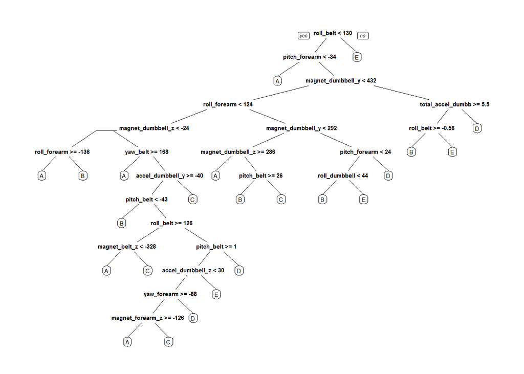

```r
treeModel <- rpart(classe ~ ., data=trainData, method="class")
prp(treeModel)
```